# Exercícios

## Aula 01

### R como calculadora

1. Calcule o número de ouro no R ($\frac{1 + \sqrt{5}}{2}$).

```r
(1 + sqrt(5))/2
(1 + 5^(1/2))/2
```

2. O que dá divisão de 1 por 0? E -1 por 0?

```r
1/0
```

```
## [1] Inf
```

```r
-1/0
```

```
## [1] -Inf
```

3. Quais as diferenças entre `NaN`, `NULL`, `NA` e `Inf`?
- `NaN` quer dizer “Not a number”, ele aparece quando o resultado de uma expressão matemática não está definida.
- `NA` significa “Not Available” e simboliza informação ausente/faltante. Usamos NA principalmente para representar dados faltantes em bancos de dados.
- `NULL` significa vazio, “nada”. Quando queremos que uma função não retorne nada, fazemos ela devolver `NULL`.
- `Inf` representa o infinito, como no limite de funções matemáticas. Valores muito grandes (10e+308) e `1/0` retornam `Inf` (com I maiúsculo).

4.a) Tente mentalmente calcular o que dá a conta `5 + 3 * 10 %/% 3 == 15` no R, sem rodar.

```r
14 == 15
```

```
## [1] FALSE
```

4.b) Adicionando apenas parênteses, faça a expressão acima retornar o resultado contrário.

```r
5 + (3 * 10) %/% 3 == 15
```

```
## [1] TRUE
```

### Flow Controls

1.a) O que acontece se eu rodar

```r
x <- 4
if(x = 4) {
  'isso aqui apareceu'
}
x
```

R: *Dará um erro de que coisas inesperadas ocorreram.*

Você notou alguma coisa estranha? Como o R se comporta nesse caso?

R: *A condição do if está utilizando o operador “=” em vez do “==”.*

1.b) Como você modificaria esse código para não dar erro e aparecer a frase ‘isso aqui apareceu’? Obs: Existem duas formas de modificar o código que farão ele funcionar.

R: Forma I

```r
if(x == 4) {
  'isso aqui apareceu'
}
```

```
## [1] "isso aqui apareceu"
```

```r
x
```

```
## [1] 4
```

R: Forma II

```r
if(x <- 4) {
  'isso aqui apareceu'
}
```

```
## [1] "isso aqui apareceu"
```

```r
x
```

```
## [1] 4
```

Esta segunda forma mostra uma das diferenças entre os operadores de atribuição `=` e `<-`.

2. Escreva a frase (em uma linha)

> 1 elefante(s) incomoda(m) muita gente  
> 2 elefante(s) incomoda(m) incomoda(m) muito mais  
> 3 elefante(s) incomoda(m) muita gente  
> 4 elefante(s) incomoda(m) incomoda(m) incomoda(m) incomoda(m) muito mais

usando `for` ou `while`.

R: Utilizando `for`:

```r
n <- 4 # número de repetições
for(i in 1:n) {
  parte1 <- paste(i, "elefante(s)")

  parte2 <- ""
  for(j in 1:ifelse(i%%2 == 0, i, 1)) {
    parte2 <- paste(parte2, "incomoda(m)")
  }

  parte3 <- ifelse(i%%2 == 0, "muito mais", "muita gente")

  verso <- paste(parte1, parte2, parte3)
  print(verso)
}
```

```
## [1] "1 elefante(s)  incomoda(m) muita gente"
## [1] "2 elefante(s)  incomoda(m) incomoda(m) muito mais"
## [1] "3 elefante(s)  incomoda(m) muita gente"
## [1] "4 elefante(s)  incomoda(m) incomoda(m) incomoda(m) incomoda(m) muito mais"
```

### Funções

1. Crie uma função que recebe um vetor de numeros e devolve a variancia.

```r
variancia <- function(x) {
  media <- mean(x)
  n <- length(x)
  var <- sum((x - media)^2)/n
  return(var)
}
```

2. Calcule a variancia de `x <- 1:100` utilizando a sua funcao criada no item 1 e utilizando a funcao `var()` do R. Compare seus resultados. Eles coincidem? Por que?

```r
x <- 1:100
variancia(x)
```

```
## [1] 833.25
```

```r
var(x)
```

```
## [1] 841.6667
```

R: Elas não coincidem, pois a função `var()` do R calcula a variância amostral (dividido por n - 1 ) em vez da variância populacional (dividido por n).

3. Altere sua função para que agora ela aceite que o usuário escolha entre qual tipo de variância ela quer calcular. Certifique-se que ela devolva a variância populacional caso o usuário não escolha explicitamente.

```r
variancia <- function(x, populacional = TRUE) {
  media <- mean(x)
  n <- length(x)
  if(!populacional) {
    n <- n - 1
  }
  var <- sum((x - media)^2)/n
  return(var)
}

# teste
variancia(x)
```

```
## [1] 833.25
```

```r
variancia(x, FALSE)
```

```
## [1] 841.6667
```

4. Construa uma função que recebe dois vetores numéricos de mesmo tamanho, `v1` e `v2`, e retorne a média ponderada de `v1` por `v2`. Calcule a média ponderada do vetor `v1 <- c(11, 9, 8, 7, 11, 6, 7, 9)` utilizando como pesos o vetor `v2 <- c(1, 2, 1, 2, 1, 2, 1, 2)`. BÔNUS: certifique que o usuario tenha passado vetores de tamanhos iguais e ambos numéricos. Retorne `NULL` caso uma dessas condições falhe.

```r
media_ponderada <- function(v1, v2) {
  if(!is.numeric(v1) | !is.numeric(v2) | length(v1) != length(v2)) { # BÔNUS
    NULL
  }

  sum(v1*v2/sum(v2))
}

v1 <- c(11, 9, 8, 7, 11, 6, 7, 9)
v2 <- c(1, 2, 1, 2, 1, 2, 1, 2)
media_ponderada(v1, v2)
```

```
## [1] 8.25
```

5. Crie uma versão da função `paste()` que una palavras pulando linhas (`\\n`)

```r
meu_paste <- function(...) {
  paste(..., sep = "\n")
}

# Teste
teste <- meu_paste("print()", "não pula linha", "cat()", "pula linha")

print(teste)
```

```
## [1] "print()\nnão pula linha\ncat()\npula linha"
```

```r
cat(teste)
```

```
## print()
## não pula linha
## cat()
## pula linha
```

6. Crie uma função que recebe um vetor de characters e um vetor numérico de mesmo comprimento e imprima um texto com os nomes dessas variáveis, um símbolo de atribuição (`<-`), e os números, separando cada expressão pulando linhas. Por exemplo:

```r
x <- letters[1:10]
y <- 10:1

imprime_coisas_legais(x, y)
```

```r
a <- 10
b <- 9
c <- 8
d <- 7
e <- 6
f <- 5
g <- 4
h <- 3
i <- 2
j <- 1
```

R:

```r
imprime_coisas_legais <- function(x, y) {
  for(i in seq_along(x)) {
    print(paste(x[i], "<-", y[i]))
  }
}

x <- letters[1:10]
y <- 10:1

imprime_coisas_legais(x, y)
```

```
## [1] "a <- 10"
## [1] "b <- 9"
## [1] "c <- 8"
## [1] "d <- 7"
## [1] "e <- 6"
## [1] "f <- 5"
## [1] "g <- 4"
## [1] "h <- 3"
## [1] "i <- 2"
## [1] "j <- 1"
```

## Aula 02

### Estruturas de dados

**1**. O senhor Adalberto é dono de uma loja e, utilizando o R, ele quer criar um cadastro de seus clientes. Para isso, ele está armazenando as informações em uma matriz da seguinte maneira:

```r
cadastro <- matrix(c(NA, NA, NA, NA), nrow = 100, ncol = 4,
                   dimnames = list(NULL, c("Nome", "Idade", "Cidade", "Telefone")))

cadastro[1,] <- c("Maria das Dores", 56, 3025-111, "São Paulo")
cadastro[2,] <- c("José Aníbal", 40, 3333-012, "Santos")
cadastro[3,] <- c("Pedro Silva", 23, 3091-777, "São Paulo")
# ...
```

1. O que faz o argumento `dimnames =`? O que significa o primeiro argumento da lista ser `NULL`?
2. O que vai acontecer se o senhor Adalberto tentar tirar a média da idade dos seus clientes fazendo `mean(cadastro[,2])`? Como ele poderia calcular essa média sem mudar a estrutura do objeto `cadastro`?
3. No lugar de `matrix`, qual seria a melhor estrutura para se utilizar neste caso?

**2**. Por que `0.1 == 0.3/3` retorna `FALSE`?

### Subsetting

**1**. Considere o `data.frame` *diamonds* do R:

1. Como você faria para permutar aleatoriamente as colunas?
2. É possível permutar linhas e colunas simultaneamente em um passo?
3. Como ordenar as colunas do banco de dados em ordem alfabética?
4. Crie uma nova variável no banco de dados que seja 1 se o preço (`price`) for menor 300 e 0 caso contrário.

**2**. Considere o vetor abaixo:

```r
x1 <- 1:8
```

1. Por que a expressao `x1 == c(2,3)` não retorna as posições de `x1` que são iguais a 2 ou 3?
2. O que faz o operador `%in%`?

### Leitura de dados

1. Vamos supor que o seu diretório de trabalho seja `"Desktop/pasta1/pasta2"` e que dentro da *pasta2* você tenha uma *pasta3*. Sem mudar o diretório de trabalho, escreva um código, utilizando a função `read.table()`, para ler um arquivo que esteja
1. dentro da *pasta3*.
2. dentro da *pasta1*.
2. É possível ler um arquivo em que o separador de valores (`sep`) é igual ao separador de casas deciamais (`dec`)?
3. Qual a diferença entre as funções `read.csv()` e `read.csv2()`?

### O operador *pipe*

1. Reescreva a expressão abaixo utilizando o operador `%>%`.

```
## stat_bin: binwidth defaulted to range/30. Use 'binwidth = x' to adjust this.
```

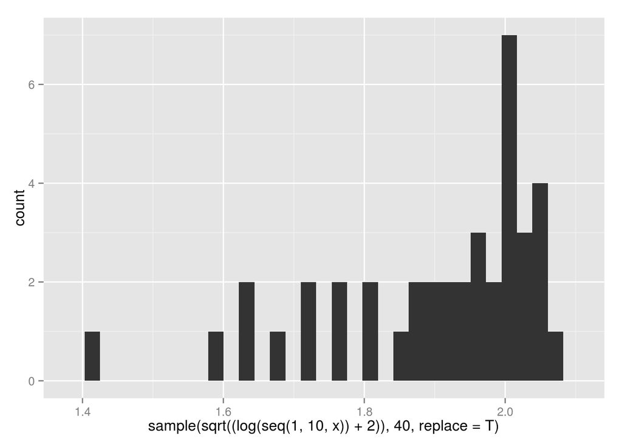

```r
x <- 0.1

library(ggplot2)

qplot(x=sample(sqrt((log(seq(1, 10, x)) + 2)), 40, replace = T), geom="histogram")
```

2. Para que servem os operadores:
1. `%<>%`?
2. `%T>%`?
3. `%$%`?

### Gráficos com o pacote *graphics*

**1**. Considere o gráfico abaixo:

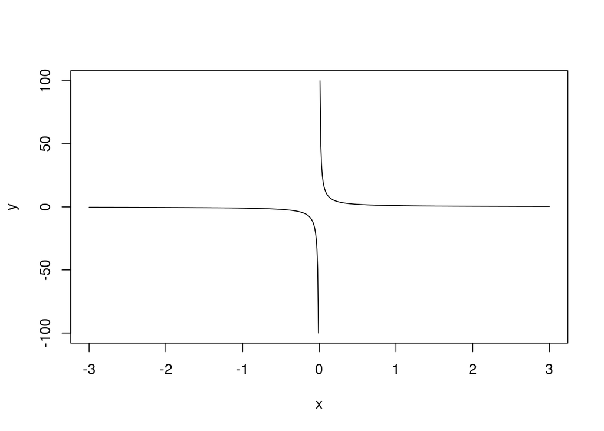

```r
x <- seq(-3, 3, 0.01)
y <- 1/x

plot(x, y, type = "l")
```

1. Altere os limites do eixo x para que o gráfico seja visualizado apenas do -2 ao 2.
2. Acrescente um título ao grafico.
3. Acrescente uma reta vertical pontilhada no ponto x = 0.
4. Acrescente uma legenda ao gráfico no “terceiro quadrante”.

**2**. Como construir dois gráficos na mesma janela?

## Aula 03

## Aula 04

## Aula 05

## Aula 06

## Aula 07

## Aula 08

## Aula 09

## Aula 10

## Aula 11

## Aula 12